# 7 Conectividad funcional: más allá del cono

**NotaEn este capítulo**

**Pregunta.** ¿Y si la matriz no es definida positiva real?

**Objetivos.** Extender la geometría afín-invariante a las matrices espectrales complejas (hermíticas definidas positivas), ver qué pasa con las matrices de correlación y con las medidas de fase que no son definidas positivas (PLV, wPLI), cuantificar el coste de forzar el wPLI dentro del cono y cerrar el libro con un mapa de decisión: qué matriz tengo, qué geometría admite y qué comprobar.

**Prerrequisitos.** Capítulos 2 (taxonomía de matrices), 4 (distancias e invariancia) y 6 (contrastes sin fugas).

**Código.** Los generadores y las funciones auxiliares son provisionales y viven en el capítulo; pasarán a `NeuroRiemann.jl` con la cohorte (apéndice D). Todo es sintético, con semilla fija.

## 7.1 La pregunta

Los capítulos anteriores trabajaron con covarianzas reales. Pero el EEG produce también matrices **complejas** (el espectro cruzado conserva la fase) y medidas de conectividad que **no son definidas positivas** (el wPLI tiene diagonal nula y es indefinido, Proposición 2.3). Con ellas hay que decidir: ¿qué geometría admite cada una?, ¿qué cuesta forzarla dentro del cono?, ¿y qué hacer cuando no hay una solución limpia?

Se trabaja con matrices hermíticas, con adjunta $P^*=\overline P^\top$ en lugar de traspuesta; las reales son el caso particular de parte imaginaria nula.

## 7.2 Matrices hermíticas definidas positivas (HPD)

**Definición 7.1 (Cono HPD y su distancia)** $\mathrm{HPD}_n$ es el conjunto de matrices hermíticas definidas positivas de $\mathbb C^{n\times n}$. Para $A,B\in\mathrm{HPD}_n$, los autovalores de $A^{-1}B$ son reales y positivos (la matriz es semejante a $A^{-1/2}BA^{-1/2}\in\mathrm{HPD}_n$), y se define, **sin factores constantes adicionales**,
$$\dAI(A,B)=\Big(\sum_{i=1}^n\log^2\lambda_i\big(A^{-1}B\big)\Big)^{1/2}=\big\|\Logm\big(A^{-1/2}BA^{-1/2}\big)\big\|_F .$$

Es la ecuación 4.4 con la adjunta en lugar de la traspuesta, y la invariancia se conserva:

**Proposición 7.1 (Invariancia afín en $\mathrm{HPD}_n$)** Para todo $W\in\mathrm{GL}(n,\mathbb C)$ y $A,B\in\mathrm{HPD}_n$, $\dAI(WAW^*,WBW^*)=\dAI(A,B)$. Demostrado

*Demostración*. $(WAW^*)^{-1}(WBW^*)=W^{-*}(A^{-1}B)W^*$ es semejante a $A^{-1}B$, y por tanto tiene los mismos autovalores.

La realificación permite usar las funciones del paquete, que son reales. Para $H\in\mathbb C^{n\times n}$ sea
$$\rho(H)=\begin{pmatrix}\operatorname{Re}H&-\operatorname{Im}H\\\operatorname{Im}H&\operatorname{Re}H\end{pmatrix}\in\R^{2n\times2n}
\tag{7.1}$$
la matriz real de la aplicación $v\mapsto Hv$ cuando $v=a+ib$ se escribe como $(a;b)$.

**Proposición 7.2 (Realificación y el factor $\sqrt2$)** $\rho(AB)=\rho(A)\rho(B)$, y si $P\in\mathrm{HPD}_n$ entonces $\rho(P)$ es simétrica definida positiva. Además, para $A,B\in\mathrm{HPD}_n$,
$$\dAI\big(\rho(A),\rho(B)\big)=\sqrt2\;\dAI(A,B),$$
donde a la izquierda es la distancia real de $\SPD_{2n}$. Demostrado

*Demostración*. La multiplicatividad es el producto de bloques. Si $P^*=P$, $(\operatorname{Re}P)^\top=\operatorname{Re}P$ y $(\operatorname{Im}P)^\top=-\operatorname{Im}P$ dan $\rho(P)^\top=\rho(P)$, y para $x=(a;b)$ con $v=a+ib$, $x^\top\rho(P)x=v^*Pv>0$. Sea $M=A^{-1}B$: por la multiplicatividad, $\rho(A)^{-1}\rho(B)=\rho(M)$. Si $Mv=\mu v$ con $\mu>0$ real, el vector real $x\leftrightarrow v$ cumple $\rho(M)x=\mu x$, y también $\rho(M)x'=\mu x'$ para $x'\leftrightarrow iv$; $x$ y $x'$ son linealmente independientes sobre $\R$. Así que cada autovalor $\mu_i$ de $M$ aparece **dos veces** en $\rho(M)$, y $\dAI(\rho(A),\rho(B))^2=2\sum_i\log^2\mu_i$.

El factor $\sqrt2$ es una convención que hay que declarar siempre: la distancia en $\mathrm{HPD}_n$ definida arriba no lo lleva, y la de las matrices reales realificadas sí. (La métrica de información de Fisher de la familia de gaussianas complejas circulares con covarianza $P$ es $\tr(P^{-1}dP\,P^{-1}dP)$, sin el factor $\tfrac12$ de la real [VERIFICAR fuente].)

**Código**

```julia
using NeuroRiemann, LinearAlgebra, StableRNGs, Statistics, Random, CairoMakie

cn(rng, dims...) = (randn(rng, dims...) .+ im .* randn(rng, dims...)) ./ sqrt(2)         # gaussiana compleja circular
const MEZCLA = [1.0 0.3 0.6; 0.8 0.5 0.6; 0.4 0.9 0.6; 0.2 1.0 0.6; 0.6 0.2 1.0; 0.3 0.7 0.9]

"Tres fuentes por segmento; la 2 sigue a la 1 con acoplamiento κ y desfase φ (como en el capítulo de registro y matriz)."
function fuentes(rng, K; κ = 0.6, φ = π / 3)
    Y1 = cn(rng, K); Y2 = κ .* cis(-φ) .* Y1 .+ sqrt(1 - κ^2) .* cn(rng, K); Y3 = cn(rng, K)
    return permutedims(hcat(Y1, Y2, Y3))
end
sensores(rng, Y; A = MEZCLA, σ = 0.3) = A * Y .+ σ .* cn(rng, size(A, 1), size(Y, 2))
espectral(Z) = Hermitian(Z * Z' / size(Z, 2))

function wpli(Z)
    n = size(Z, 1); W = zeros(n, n)
    for i in 1:n, j in 1:n
        i == j && continue
        x = imag.(Z[i, :] .* conj.(Z[j, :]))
        W[i, j] = abs(sum(x)) / sum(abs, x)
    end
    return Symmetric(W)
end

dHPD(A, B) = sqrt(sum(abs2, log.(eigvals(Hermitian(B), Hermitian(A)))))              # autovalores generalizados B v = λ A v
rho(H) = [real(H) -imag(H); imag(H) real(H)]                                          # @eq-realificacion
dAI(A, B) = distance(AffineInvariant(), A, B)

"Clasificación de una matriz según la taxonomía del capítulo 2: tipo, rango, condicionamiento y geometría que admite."
function diagnostica(M; tol = 1e-10)
    norm(M - M') <= 1e-8 * max(norm(M), 1) || return (tipo = "no hermítica", rango = missing, κ = missing, geometría = "fuera de este libro")
    λ = eigvals(Hermitian(M)); λmax = max(abs(first(λ)), abs(last(λ)))
    real_ = all(isreal, M); unidad = all(i -> abs(M[i, i] - 1) < 1e-8, 1:size(M, 1))
    rango = count(x -> abs(x) > tol * λmax, λ)                       # autovalores no nulos
    if first(λ) > tol * λmax
        tipo = (real_ ? "SPD" : "HPD") * (unidad ? " con diagonal unitaria" : "")
        geometría = real_ ? "cono SPD: euclídea, log-euclídea o afín-invariante" : "cono HPD: afín-invariante hermítica"
        return (; tipo, rango, κ = last(λ) / first(λ), geometría)
    elseif first(λ) >= -tol * λmax
        return (tipo = "semidefinida", rango, κ = Inf, geometría = "reducir el rango o contraer antes de usar distancias")
    end
    return (tipo = "indefinida", rango, κ = missing, geometría = "fuera del cono: desplazar, recortar, núcleo o trabajar con el vector")
end
nothing
```

Comprobamos las dos afirmaciones con matrices espectrales del modelo del capítulo 2 (200 segmentos):

**Código**

```julia
rng = StableRNG(5)
A = espectral(sensores(rng, fuentes(rng, 200))); B = espectral(sensores(rng, fuentes(rng, 200; κ = 0.0)))
W = randn(rng, 6, 6) + im * randn(rng, 6, 6)                                          # congruencia compleja cualquiera
(invariancia = abs(dHPD(W * A * W', W * B * W') - dHPD(A, B)) / dHPD(A, B),
 razón_realificada = dAI(Symmetric(rho(A)), Symmetric(rho(B))) / dHPD(A, B), raíz_de_2 = sqrt(2))
```

```
(invariancia = 3.532148697109924e-15, razón_realificada = 1.4142135623730954, raíz_de_2 = 1.4142135623730951)
```

La primera cantidad es del orden del error de máquina y la razón vale $\sqrt2$ Verificado numéricamente.

## 7.3 Correlación y coherencia

La **coherencia compleja** $\hat C=D^{-1/2}\hat SD^{-1/2}$ es HPD con diagonal unitaria y la **coherencia al cuadrado** es SPD con diagonal unitaria (Proposición 2.2). Las matrices de correlación forman el conjunto $\Corr_n=\{P\in\SPD_n:P_{ii}=1\}$, que es un subconjunto de $\SPD_n$ y no un cono. ¿Sirve la geometría afín-invariante dentro de él?

**Proposición 7.3 (La geodésica afín-invariante sale de $\Corr_n$)** Sean $A=\begin{pmatrix}1&a\\a&1\end{pmatrix}$ y $B=\begin{pmatrix}1&b\\b&1\end{pmatrix}$ con $|a|,|b|<1$ y $a\ne b$. Para todo $t\in(0,1)$ los elementos diagonales de $\gamma_{AI}(t)$ son estrictamente menores que $1$, de modo que $\gamma_{AI}(t)\notin\Corr_2$. Demostrado

*Demostración*. $A$ y $B$ conmutan (tienen los autovectores $(1,\pm1)/\sqrt2$, con autovalores $1\pm a$ y $1\pm b$), así que por la Proposición 4.4 $\gamma_{AI}(t)$ tiene esos mismos autovectores y autovalores $(1\pm a)^{1-t}(1\pm b)^t$, y su elemento diagonal es $\tfrac12\sum_{\pm}(1\pm a)^{1-t}(1\pm b)^t$. Por la desigualdad de Hölder con exponentes $\tfrac1{1-t}$ y $\tfrac1t$, $\sum_{\pm}(1\pm a)^{1-t}(1\pm b)^t\le\big(\sum_\pm(1\pm a)\big)^{1-t}\big(\sum_\pm(1\pm b)\big)^t=2$, con igualdad si y solo si los vectores $(1+a,1-a)$ y $(1+b,1-b)$ son proporcionales, es decir, $a=b$.

Es decir, **la media y las geodésicas de correlaciones ya no son correlaciones**, y hay que renormalizar o elegir una geometría de cociente (que se menciona sin desarrollar [VERIFICAR fuente]). La distancia $\dAI$ restringida a $\Corr_n$ sigue siendo una distancia, pero su geodésica no pertenece a $\Corr_n$.

**Código**

```julia
a, b = 0.2, 0.8
Aa, Bb = [1 a; a 1], [1 b; b 1]
mid = interpolate(AffineInvariant(), Aa, Bb, 0.5)
(diagonal_numérica = diag(mid), diagonal_fórmula = (sqrt((1 + a) * (1 + b)) + sqrt((1 - a) * (1 - b))) / 2)
```

```
(diagonal_numérica = [0.9348469228349526, 0.9348469228349526], diagonal_fórmula = 0.9348469228349534)
```

### 7.3.1 Conducción de volumen: coherencia inflada

La coherencia mide la dependencia, no el retardo, y una fuente común a los sensores la infla (capítulo 2, Proposición 2.6). Con **cero acoplamiento** entre las fuentes 1 y 2, se aumenta el peso $v_c$ de la fuente común:

**Código**

```julia
function medidas_vc(vc; K = 300, R = 200)
    rng = StableRNG(round(Int, 100vc) + 3)
    r = map(1:R) do _
        Y1, Y2, Y3 = cn(rng, K), cn(rng, K), cn(rng, K)
        Z1 = Y1 .+ 0.5 .* Y2 .+ vc .* Y3; Z2 = 0.4 .* Y1 .+ Y2 .+ vc .* Y3; x = Z1 .* conj.(Z2)
        nrm = sqrt(sum(abs2, Z1) * sum(abs2, Z2))
        (abs(sum(x)) / nrm, abs(imag(sum(x))) / nrm, abs(sum(imag.(x))) / sum(abs, imag.(x)))
    end
    return (coherencia = mean(first.(r)), imaginaria = mean(getindex.(r, 2)), wPLI = mean(getindex.(r, 3)))
end
println("| Peso de la fuente común \$v_c\$ | Coherencia | Coherencia imaginaria | wPLI |\n|---|---|---|---|")
for vc in (0.0, 0.5, 1.0, 2.0)
    m = medidas_vc(vc)
    println("| ", vc, " | ", round(m.coherencia; digits = 3), " | ", round(m.imaginaria; digits = 3), " | ", round(m.wPLI; digits = 3), " |")
end
println("\n: Medidas entre dos sensores sin acoplamiento entre fuentes, al crecer la fuente común (300 segmentos, 200 réplicas). {#tbl-vc}")
```

Tabla 7.1: Medidas entre dos sensores sin acoplamiento entre fuentes, al crecer la fuente común (300 segmentos, 200 réplicas).

| Peso de la fuente común $v_c$ | Coherencia | Coherencia imaginaria | wPLI |
| --- | --- | --- | --- |
| 0.0 | 0.749 | 0.021 | 0.063 |
| 0.5 | 0.79 | 0.018 | 0.059 |
| 1.0 | 0.864 | 0.019 | 0.074 |
| 2.0 | 0.942 | 0.012 | 0.071 |

La coherencia sube con la fuente común y las medidas de fase no (Tabla 7.1) Verificado numéricamente: sin parte imaginaria no hay evidencia de retardo. Con $v_c=0$ la coherencia ya es alta porque los dos sensores comparten las fuentes 1 y 2 por la mezcla.

## 7.4 El PLV tampoco tiene por qué ser definido positivo

El PLV entre los canales $i$ y $j$ es el módulo del promedio de $e^{i(\theta_{k,i}-\theta_{k,j})}$ sobre los segmentos $k$. La matriz $R=\tfrac1K\sum_kz_kz_k^*$ con $z_k=(e^{i\theta_{k,1}},\dots,e^{i\theta_{k,n}})$ es semidefinida positiva con diagonal unitaria, pero el PLV es $|R_{ij}|$: el módulo **entrada a entrada**, y esa operación no conserva la positividad.

**Proposición 7.4 (Un PLV indefinido con $n=4$)** Con $K=2$ segmentos y fases $z_1=(1,1,1,1)$ y $z_2=(1,i,-1,-i)$, la matriz $\mathrm{PLV}=(|R_{ij}|)$ es la circulante de primera fila $\big(1,\tfrac{\sqrt2}2,0,\tfrac{\sqrt2}2\big)$, con autovalores $1+\sqrt2,\ 1,\ 1-\sqrt2,\ 1$: es **indefinida**. Demostrado

*Demostración*. $R_{jk}=\tfrac12\big(1+i^{\,j-k}\big)$, de modo que $|R_{jk}|=|\cos(\tfrac\pi4(j-k))|$, que vale $1$, $\tfrac{\sqrt2}2$, $0$, $\tfrac{\sqrt2}2$ para $|j-k|\bmod4=0,1,2,3$. Es circulante, y los autovalores de una circulante de primera fila $(c_0,c_1,c_2,c_3)$ son $\sum_mc_m\omega^{mk}$ con $\omega=i$: $1+\tfrac{\sqrt2}2(i^k+i^{-k})=1+\sqrt2\cos\tfrac{\pi k}2$ para $k=0,\dots,3$.

Es un contraejemplo, no un resultado típico: lo que enseña es que **ninguna medida de fase entrada a entrada hereda la positividad del espectro cruzado**, y que antes de usar una distancia hay que mirar los autovalores.

## 7.5 El wPLI y cinco vías hacia una matriz definida

La matriz de wPLI es simétrica, con entradas en $[0,1]$ y diagonal nula, y por tanto indefinida (Proposición 2.3). Hay cinco maneras de tratarla, cada una con su coste:

Tabla 7.2: Vías para llevar el wPLI al cono.

| Vía | Qué se hace | Qué cuesta |
| --- | --- | --- |
| **1. Desplazar** | $W+cI$ con $c>-\lambda_{\min}(W)$ | las distancias dependen de $c$ (Experimento 1) |
| **2. Recortar** | proyectar sobre las matrices semidefinidas, poniendo a cero los autovalores negativos | el resultado es singular: hay que añadir un $\epsilon$ arbitrario para usar $\dAI$ |
| **3. Núcleo** | $K=\exp(-\tau L)$ con $L=\operatorname{diag}(W\mathbf 1)-W$ (laplaciana del grafo ponderado) | siempre SPD, pero depende de $\tau$ y cambia el significado: $K$ mide difusión, no conectividad |
| **4. Gram** | $WW^\top+\epsilon I$ | mide la similitud entre **perfiles de conexión**, no la conectividad; singular sin $\epsilon$ |
| **5. No forzar** | tratar la parte triangular superior de $W$ como un vector y usar la distancia euclídea | se pierde la estructura matricial y la geometría del cono |

La convención más frecuente, $W+I$, **no garantiza** nada. Para $n=3$ y $W=J-I$ (todas las conexiones iguales a $1$), $W$ tiene autovalores $-1,-1,2$ y $W+I=J$ es singular. En una cohorte real o sintética, $\lambda_{\min}$ varía entre sujetos, y el $c$ común debe superar el mayor $-\lambda_{\min}$.

**Proposición 7.5 (El recorte es la proyección más próxima)** Sea $W=U\Lambda U^\top$ simétrica y $W_+=U\max(\Lambda,0)U^\top$. Entonces $W_+$ es la matriz semidefinida positiva más próxima a $W$ en norma de Frobenius, con $\|W-W_+\|_F^2=\sum_{\lambda_i<0}\lambda_i^2$. Demostrado

*Demostración*. Para $X$ semidefinida positiva sea $Y=U^\top XU$, también semidefinida positiva, de modo que $y_{ii}\ge0$. Por la invarianza ortogonal de la norma de Frobenius, $\|W-X\|_F^2=\|\Lambda-Y\|_F^2\ge\sum_i(\lambda_i-y_{ii})^2\ge\sum_{\lambda_i<0}\lambda_i^2$, y se alcanza con $Y=\max(\Lambda,0)$.

Con la restricción adicional de diagonal unitaria el problema es el de la matriz de correlación más próxima, que no tiene fórmula cerrada y se resuelve iterativamente Citado (Higham 2002).

**Proposición 7.6 (Qué le hace $c$ a la distancia)** Sean $W_1,W_2$ simétricas. Cuando $c\to\infty$, $\dAI(W_1+cI,W_2+cI)=\dfrac{\|W_1-W_2\|_F}{c}+O(c^{-2})$. Si, por el contrario, $c$ decrece hasta que $W_1+cI$ se hace singular sin que lo haga $W_2+cI$, $\dAI(W_1+cI,W_2+cI)\to\infty$. Demostrado

*Demostración*. Sea $X=W_1+cI$ e $Y=W_2+cI$. Para $c$ grande, $X^{-1/2}YX^{-1/2}=I+\tfrac1c(W_2-W_1)+O(c^{-2})$, y $\Logm(I+E)=E+O(\|E\|^2)$ da el primer límite en norma de Frobenius. Para el segundo, sea $x$ un autovector unitario de $X$ con autovalor $\varepsilon\to0$: el mayor autovalor generalizado de $Y v=\lambda Xv$ es al menos $x^\top Yx/x^\top Xx=x^\top Yx/\varepsilon\to\infty$ porque $x^\top Yx>0$ si $Y$ es definida positiva.

Es decir, cuanto más grande es $c$, **menos distancia hay y más se parece a la euclídea sobre $W$** (una distancia que ya se podía calcular sin llevar $W$ al cono), y cuanto más cerca de la frontera, más domina el menor autovalor.

## 7.6 Experimento 1: la geometría del wPLI depende de la vía

Doce sujetos sintéticos de seis sensores, con acoplamiento y retardo propios, con mezcla ligeramente distinta por sujeto y 60 segmentos. Se calcula la matriz de wPLI de cada uno y las 66 distancias $\dAI$ entre pares tras desplazar con distintos $c$.

**Código**

```julia
function cohorte_wpli(; N = 12, K = 60)
    rng = StableRNG(77)
    return map(1:N) do _
        A = MEZCLA .* (1 .+ 0.2 .* randn(rng, 6, 3))
        wpli(sensores(rng, fuentes(rng, K; κ = 0.3 + 0.5 * rand(rng), φ = 0.3 + 0.9 * rand(rng)); A = A))
    end
end
Ws = cohorte_wpli()
N = length(Ws)
pares = [(i, j) for i in 1:N for j in i+1:N]
frob = [norm(Ws[i] - Ws[j]) for (i, j) in pares]
c0 = -minimum(first(eigvals(W)) for W in Ws)
rangos(x) = invperm(sortperm(x))
spearman(x, y) = cor(rangos(x), rangos(y))
distancias(c) = [dAI(Ws[i] + c * I, Ws[j] + c * I) for (i, j) in pares]
cs = [c0 + 0.02, c0 + 0.1, c0 + 0.5, 2.0, 5.0, 20.0, 100.0]
referencia = distancias(100.0)
tabla = [(c, d = distancias(c)) for c in cs]
println("Los autovalores mínimos de las \$$(N)\$ matrices van de \$$(round(minimum(first(eigvals(W)) for W in Ws); digits = 2))\$ a \$$(round(maximum(first(eigvals(W)) for W in Ws); digits = 2))\$; hace falta \$c>$(round(c0; digits = 2))\$. Con \$c=1\$ (la convención \$W+I\$) alguna matriz no es definida positiva: \$\\lambda_{\\min}(W+I)=$(round(1 - c0; digits = 2))\$.\n")
println("| \$c\$ | Distancia media | \$c\\,d_{AI}/\\|W_i-W_j\\|_F\$ medio | Orden de los pares frente a Frobenius (Spearman) | Orden frente al de \$c\$ más próximo a la frontera |\n|---|---|---|---|---|")
for t in tabla
    println("| ", round(t.c; digits = 2), " | ", round(mean(t.d); sigdigits = 3), " | ", round(mean(t.c .* t.d ./ frob); digits = 3), " | ", round(spearman(t.d, frob); digits = 3), " | ", round(spearman(t.d, tabla[1].d); digits = 3), " |")
end
println("\n: Distancias afín-invariantes entre las matrices de wPLI desplazadas por \$cI\$ (66 pares de 12 sujetos). {#tbl-desplazamiento}")
```

Los autovalores mínimos de las $12$ matrices van de $-1.26$ a $-0.25$; hace falta $c>1.26$. Con $c=1$ (la convención $W+I$) alguna matriz no es definida positiva: $\lambda_{\min}(W+I)=-0.26$.

Tabla 7.3: Distancias afín-invariantes entre las matrices de wPLI desplazadas por $cI$ (66 pares de 12 sujetos).

| $c$ | Distancia media | $c\,d_{AI}/\\|W_i-W_j\\|_F$ medio | Orden de los pares frente a Frobenius (Spearman) | Orden frente al de $c$ más próximo a la frontera |
| --- | --- | --- | --- | --- |
| 1.28 | 2.02 | 1.849 | 0.686 | 1.0 |
| 1.36 | 1.52 | 1.499 | 0.781 | 0.983 |
| 1.76 | 0.893 | 1.146 | 0.912 | 0.892 |
| 2.0 | 0.744 | 1.083 | 0.936 | 0.855 |
| 5.0 | 0.267 | 0.969 | 0.991 | 0.727 |
| 20.0 | 0.0685 | 0.983 | 0.998 | 0.696 |
| 100.0 | 0.0139 | 0.996 | 1.0 | 0.69 |

**Código**

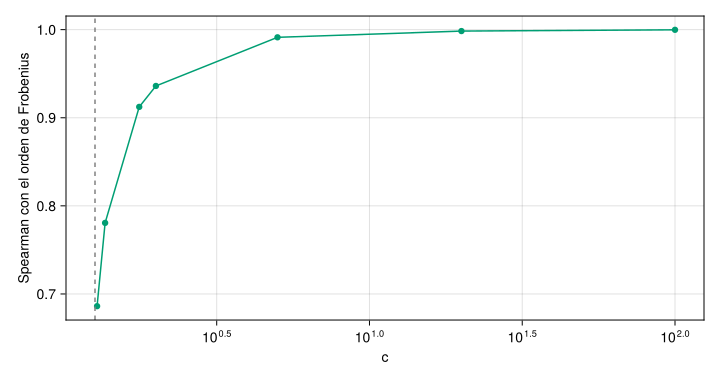

Figura 7.1: Orden de los pares de sujetos tras desplazar el wPLI con $c$ (correlación de Spearman con el orden de la distancia de Frobenius entre las matrices originales) frente a $c$. Cerca de la frontera el orden es otro; con $c$ grande converge al euclídeo.

```julia
colores = Makie.wong_colors()
fig = Figure(size = (720, 380))
ax = Axis(fig[1, 1]; xscale = log10, xlabel = "c", ylabel = "Spearman con el orden de Frobenius")
scatterlines!(ax, [t.c for t in tabla], [spearman(t.d, frob) for t in tabla]; color = colores[3])
vlines!(ax, [c0]; color = :gray, linestyle = :dash)
fig
```

La Tabla 7.3 confirma la Proposición 7.6 Verificado numéricamente: el cociente $c\,d_{AI}/\|W_i-W_j\|_F$ tiende a $1$ cuando $c$ crece, y la distancia se anula (la geometría se «aplana»). Y lo que importa para un estudio: **el orden de los pares de sujetos depende de $c$**. Cerca de la frontera, el menor autovalor domina y el orden se parece poco al de la distancia euclídea sobre $W$ (Figura 7.1); lejos, converge a él. Elegir $c$ no es un detalle de implementación: es una hipótesis sobre qué significa «próximo» y debe fijarse **antes** de comparar grupos (capítulo 6).

Y las cinco vías de la Tabla 7.2, aplicadas a las mismas matrices: el orden de los pares frente al de Frobenius sobre las $W$ originales.

**Código**

```julia
recorte(W; ε = 1e-3) = (F = eigen(W); Symmetric(F.vectors * Diagonal(max.(F.values, 0) .+ ε) * F.vectors'))
nucleo(W, τ) = expm(-τ * Symmetric(Diagonal(vec(sum(W; dims = 2))) - W))
vias = [("1. Desplazar, \$c=c_0+0{,}1\$", W -> Symmetric(W + (c0 + 0.1) * I)), ("1. Desplazar, \$c=2\$", W -> Symmetric(W + 2I)),
        ("2. Recortar y sumar \$\\epsilon=10^{-3}\$", recorte), ("3. Núcleo \$e^{-\\tau L}\$, \$\\tau=0{,}5\$", W -> nucleo(W, 0.5)),
        ("4. Gram \$WW^\\top+10^{-3}I\$", W -> Symmetric(W * W' + 1e-3 * I))]
println("| Vía | \$\\lambda_{\\min}\$ del primer sujeto | Orden frente a Frobenius (Spearman) |\n|---|---|---|")
for (nombre, f) in vias
    Ks = [f(W) for W in Ws]
    d = [dAI(Ks[i], Ks[j]) for (i, j) in pares]
    println("| ", nombre, " | ", round(first(eigvals(Ks[1])); sigdigits = 2), " | ", round(spearman(d, frob); digits = 3), " |")
end
println("\n: Orden de las distancias entre sujetos según la vía, frente al orden de Frobenius de las matrices de wPLI originales. {#tbl-vias-orden}")
```

Tabla 7.4: Orden de las distancias entre sujetos según la vía, frente al orden de Frobenius de las matrices de wPLI originales.

| Vía | $\lambda_{\min}$ del primer sujeto | Orden frente a Frobenius (Spearman) |
| --- | --- | --- |
| 1. Desplazar, $c=c_0+0{,}1$ | 0.75 | 0.781 |
| 1. Desplazar, $c=2$ | 1.4 | 0.936 |
| 2. Recortar y sumar $\epsilon=10^{-3}$ | 0.001 | 0.424 |
| 3. Núcleo $e^{-\tau L}$, $\tau=0{,}5$ | 0.38 | 0.972 |
| 4. Gram $WW^\top+10^{-3}I$ | 0.011 | 0.647 |

Las vías dan órdenes distintos de los mismos doce sujetos (Tabla 7.4): ninguna es «la» geometría del wPLI. **No hay una elección sin coste**: hay que declarar la vía, justificarla por lo que se quiere medir y comprobar que las conclusiones no cambian con ella.

## 7.7 Experimento 2: la fase no está en la parte real

Todo lo anterior supone que la fase importa. La covarianza usa solo $\operatorname{Re}S$. Si dos situaciones difieren por un retardo $\varphi=\pi/2$, su acoplamiento tiene parte real nula y **la covarianza no las distingue**; el espectro cruzado completo, sí. Se compara «sin acoplamiento» con «acoplamiento $\kappa=0{,}6$ y retardo $\pi/2$» con 100 réplicas, y se toma como referencia el suelo de ruido: la distancia entre dos réplicas de la misma situación.

**Código**

```julia
function experimento_fase(; Ks = (60, 400, 4000), R = 100)
    rng = StableRNG(5)
    return map(Ks) do K
        r = map(1:R) do _
            S0 = espectral(sensores(rng, fuentes(rng, K; κ = 0.0)))
            S1 = espectral(sensores(rng, fuentes(rng, K; κ = 0.6, φ = π / 2)))
            S0b = espectral(sensores(rng, fuentes(rng, K; κ = 0.0)))
            (dHPD(S0, S1), dAI(Symmetric(real.(S0)), Symmetric(real.(S1))), dHPD(S0, S0b), dAI(Symmetric(real.(S0)), Symmetric(real.(S0b))))
        end
        (; K, hpd = mean(first.(r)), re = mean(getindex.(r, 2)), suelo_hpd = mean(getindex.(r, 3)), suelo_re = mean(getindex.(r, 4)))
    end
end
res_fase = experimento_fase()
println("| Segmentos \$K\$ | \$d_{HPD}\$ entre situaciones | \$d_{AI}\$ entre \$\\operatorname{Re}S\$ | suelo de \$d_{HPD}\$ | suelo de \$d_{AI}\$ (\$\\operatorname{Re}S\$) |\n|---|---|---|---|---|")
for r in res_fase
    println("| ", r.K, " | ", round(r.hpd; digits = 2), " | ", round(r.re; digits = 2), " | ", round(r.suelo_hpd; digits = 2), " | ", round(r.suelo_re; digits = 2), " |")
end
println("\n: Distancia entre «sin acoplamiento» y «acoplamiento con retardo \$\\pi/2\$» usando el espectro cruzado completo o solo su parte real (100 réplicas). {#tbl-fase}")
```

Tabla 7.5: Distancia entre «sin acoplamiento» y «acoplamiento con retardo $\pi/2$» usando el espectro cruzado completo o solo su parte real (100 réplicas).

| Segmentos $K$ | $d_{HPD}$ entre situaciones | $d_{AI}$ entre $\operatorname{Re}S$ | suelo de $d_{HPD}$ | suelo de $d_{AI}$ ($\operatorname{Re}S$) |
| --- | --- | --- | --- | --- |
| 60 | 1.46 | 0.82 | 1.1 | 0.84 |
| 400 | 0.98 | 0.32 | 0.42 | 0.32 |
| 4000 | 0.89 | 0.1 | 0.13 | 0.1 |

Con la parte real, la distancia entre las dos situaciones **no supera el suelo de ruido** para ningún $K$ (Tabla 7.5): la covarianza es ciega al retardo. Con el espectro cruzado completo, la distancia se separa del suelo y se estabiliza en un valor positivo al crecer $K$, mientras que el suelo baja Verificado numéricamente. Es la razón de tener una geometría HPD y de que **la representación importe tanto como la métrica** (P1 del capítulo 1).

## 7.8 Límites del enfoque

- **Dimensión.** Con $n$ grande y pocos segmentos, el espectro cruzado es singular (Teorema 2.1) y $\dAI$ amplifica el ruido del menor autovalor (capítulo 3); cada frecuencia tiene su propia matriz y hay que decidir qué banda y qué estimador de $S(f)$ se usa (NeuroMIND).
- **No estacionariedad.** Todo supone estacionariedad dentro de la época. Con señales que cambian en el tiempo, la matriz promediada mezcla estados y no hay garantía de que sea representativa.
- **Interpretabilidad.** Una distancia entre matrices es un número global: no dice en qué sensores ni en qué par de regiones difieren dos registros. El espacio tangente (capítulo 5) permite volver a las entradas, pero con la distorsión que allí se midió.
- **Coste.** Cada distancia afín-invariante cuesta una descomposición espectral generalizada, $O(n^3)$; la media de Karcher, $N$ de ellas por iteración. En alta dimensión el coste se suma al problema de estimación.
- **Medidas de fase.** El PLV y el wPLI son estimadores por pares, con sesgo que depende del número de segmentos (capítulo 2); este libro no estudia cómo se calculan sino qué estructura tienen.

## 7.9 Mapa de decisión

Resumen de todo el libro como una cadena de preguntas. Se aplica a una matriz concreta con `diagnostica`:

```
flowchart TD
  A["¿Qué matriz tengo?"] --> B{"Entradas"}
  B -->|reales| C{"Autovalores"}
  B -->|complejas| D{"Autovalores"}
  C -->|todos positivos| E["SPD: euclídea, log-euclídea o afín-invariante"]
  C -->|alguno nulo| F["Semidefinida: reducir el rango o contraer antes de calcular distancias"]
  C -->|alguno negativo| G["Indefinida: wPLI, coherencia imaginaria, PLV"]
  D -->|todos positivos| H["HPD: afín-invariante hermítica; la parte real si solo importa la potencia"]
  D -->|alguno nulo| F
  G --> I["Declarar una vía: desplazar, recortar, núcleo, Gram o trabajar con el vector"]
  E --> J["Centro y dispersión de Fréchet; contraste por permutación a nivel de sujeto"]
  H --> J
  I --> J
  J --> K["Compararse siempre con log-varianza y euclídea, con las mismas matrices y particiones, sin fugas"]
```

Figura 7.2: Mapa de decisión: de la matriz que se tiene a la geometría, el centro y el contraste que admite.

**Código**

```julia
rng_d = StableRNG(2026)
Z_d = sensores(rng_d, fuentes(rng_d, 400))
S_d = espectral(Z_d)
Cd = Hermitian(Diagonal(1 ./ sqrt.(real.(diag(S_d)))) * S_d * Diagonal(1 ./ sqrt.(real.(diag(S_d)))))
W_d = wpli(Z_d)
Rplv = (ones(4) * ones(4)' + cis.([0, π / 2, π, 3π / 2]) * cis.([0, π / 2, π, 3π / 2])') / 2
H_d = I - ones(6, 6) / 6
casos_d = [("Covarianza de banda (parte real de \$S\$)", Symmetric(real.(S_d))), ("Espectro cruzado \$S\$", S_d),
           ("Coherencia compleja", Cd), ("wPLI", W_d), ("wPLI + cI con c = c₀ + 0,1", Symmetric(W_d + (-first(eigvals(W_d)) + 0.1) * I)),
           ("PLV del contraejemplo (n = 4)", Symmetric(abs.(Rplv))), ("Covarianza con referencia promedio", Symmetric(H_d * real.(S_d) * H_d))]
println("| Matriz | Tipo | Rango | Geometría que admite |\n|---|---|---|---|")
for (nombre, M) in casos_d
    d = diagnostica(Matrix(M))
    println("| ", nombre, " | ", d.tipo, " | ", d.rango, " | ", d.geometría, " |")
end
println("\n: Diagnóstico de las matrices del libro con la función `diagnostica`. {#tbl-diagnostico}")
```

Tabla 7.6: Diagnóstico de las matrices del libro con la función `diagnostica`.

| Matriz | Tipo | Rango | Geometría que admite |
| --- | --- | --- | --- |
| Covarianza de banda (parte real de $S$) | SPD | 6 | cono SPD: euclídea, log-euclídea o afín-invariante |
| Espectro cruzado $S$ | HPD | 6 | cono HPD: afín-invariante hermítica |
| Coherencia compleja | HPD con diagonal unitaria | 6 | cono HPD: afín-invariante hermítica |
| wPLI | indefinida | 6 | fuera del cono: desplazar, recortar, núcleo o trabajar con el vector |
| wPLI + cI con c = c₀ + 0,1 | SPD | 6 | cono SPD: euclídea, log-euclídea o afín-invariante |
| PLV del contraejemplo (n = 4) | indefinida | 4 | fuera del cono: desplazar, recortar, núcleo o trabajar con el vector |
| Covarianza con referencia promedio | semidefinida | 5 | reducir el rango o contraer antes de usar distancias |

El diagnóstico reproduce la taxonomía del capítulo 2 (Tabla 7.6) y es el primer paso antes de elegir una distancia. Lo que **no** decide es la pregunta de fondo del libro: si, en un problema concreto, la geometría elegida aporta algo frente a la log-varianza o la distancia euclídea. Eso se responde con los criterios del capítulo 1 y los contrastes del capítulo 6.

## 7.10 Lo que esto no demuestra

- **No demuestra que la geometría HPD sea la adecuada para el EEG.** Demuestra la invariancia y el factor $\sqrt2$ de la realificación; la utilidad de la distancia hermítica frente a las alternativas se contrasta con la misma metodología del capítulo 6, que aquí no se repite para matrices complejas.
- **Los experimentos son mínimos.** Seis sensores, tres fuentes y una frecuencia; las conclusiones del Experimento 1 valen para esa cohorte. El orden de los pares de sujetos y los valores de la Tabla 7.4 dependen de la cohorte y de los parámetros elegidos ($\epsilon$, $\tau$).
- **El contraejemplo del PLV es un caso construido,** no una estimación típica. Muestra que no hay garantía, no que el PLV real sea indefinido con frecuencia.
- **La distancia de correlación no está resuelta.** Se prueba que la geodésica sale de $\Corr_n$ y se menciona la geometría de cociente, pero no se desarrolla ni se compara.
- **No se compara ninguna vía de la Tabla 7.2 en potencia estadística,** solo en cómo reordena las distancias entre sujetos.
- **El estimador del wPLI es sesgado con pocos segmentos** y no se corrige aquí.
- **Dos afirmaciones están por verificar:** la forma de la métrica de Fisher compleja y la geometría de cociente para correlaciones (marcadas `[VERIFICAR]`).

## 7.11 Autoevaluación

**TipRealificar**

Se realifica una matriz HPD de tamaño $n$ para usar funciones reales. ¿Qué factor aparece en la distancia afín-invariante y por qué?

**Respuesta.** $\sqrt2$ (Proposición 7.2): cada autovalor de $A^{-1}B$ aparece dos veces en la matriz real de tamaño $2n$.

**TipUna media de correlaciones**

Se calcula la media geométrica de dos matrices de correlación con la geometría afín-invariante. ¿Es una matriz de correlación?

**Respuesta.** En general no: su diagonal es menor que $1$ (Proposición 7.3). Hay que renormalizar o usar otra geometría.

**TipElegir c**

Dos analistas comparan sujetos con $W+cI$, uno con $c=1{,}3$ y otro con $c=20$. ¿Esperas el mismo orden de los pares de sujetos?

**Respuesta.** No necesariamente: cerca de la frontera domina el menor autovalor y con $c$ grande el orden converge al de la distancia euclídea entre las $W$ (Proposición 7.6, Tabla 7.3).

**TipInvariancia y fase (repaso del capítulo 4)**

¿Es la distancia afín-invariante entre covarianzas reales sensible al retardo entre canales?

**Respuesta.** Solo a través de la parte real del espectro cruzado. Con un retardo de $\pi/2$ el acoplamiento es imaginario puro y la covarianza no lo ve (Experimento 2).

## 7.12 Ejercicios

**Ejercicio 7.1** Para $n=1$, $A=a>0$ y $B=b>0$ (matrices $1\times1$ hermíticas), comprueba que $\dAI(A,B)=|\ln(b/a)|$ y que la realificada vale $\sqrt2\,|\ln(b/a)|$.

**Ejercicio 7.2** Generaliza el contraejemplo de la Proposición 7.4: para $n=4$ y $K=2$ segmentos con fases $z_1=\mathbf 1$ y $z_2=(1,e^{i\alpha},e^{2i\alpha},e^{3i\alpha})$, calcula los autovalores de la matriz PLV y encuentra los $\alpha$ para los que es indefinida.

**Ejercicio 7.3** Para $W=\begin{pmatrix}0&a&b\\a&0&c\\b&c&0\end{pmatrix}$ con $a,b,c>0$, da una condición suficiente sobre $c$ para que $W+cI$ sea definida positiva, usando $\lambda_{\min}(W)\ge-\|W\|_F$.

**Ejercicio 7.4** Con la cohorte del Experimento 1, compara la vía del recorte con $\epsilon\in\{10^{-6},10^{-3},10^{-1}\}$: ¿cuánto cambia el orden de los pares? ¿Y el número de condición?

**Ejercicio 7.5** (Laboratorio) Extiende `diagnostica` para que, en el caso indefinido, devuelva también el menor $c$ que hace definida positiva la matriz desplazada y el tamaño del recorte $\|W-W_+\|_F$ de la Proposición 7.5.

Higham, Nicholas J. 2002. «Computing the nearest correlation matrix—a problem from finance». *IMA Journal of Numerical Analysis* 22 (3): 329-43. https://doi.org/10.1093/imanum/22.3.329.